# Continuous-time Markov chains

# The Markov property

Suppose we want to generalize finite state discrete-time Markov chains to allow the possibility of switching states at a random time rather than at unit times. It turns out that if we want to preserve the Markov property, due to the memoryless property of the exponential distribution, the jump times have to be exponential.

Let $S$ be a finite or countable set. We say that a random process $X \in S^{ [0, \infty)}$ a **continuous-time** process taking values in $S$ and we say it satisfies the **Markov property** if

$$\mathbb{P} (X(t_n) = j | X(t_0) = a_0,
\ldots X(t_{n-2}) = a_{n-2}, X(t_{n-1}) = i) ) = \mathbb{P} (X(t_n) =
j | X(t_{n-1}) = i)$$

for all choices of $a_0, \ldots, a_{n-2}, i,j \in S$ and any sequence of times $0 \leq t_0 < t_1 < \cdots t_{n-1} < t_n < \infty.$

The Poisson counting process $N$ with i.i.d. exponential inter-arrvial times satisfies the Markov property as a consequence of the memoryless property of exponential random variables. Notice that if we appeal to the independent increment property for $N$, we have for example

$$\mathbb{P}( [N(101) - N(100) =0], N(100)
=0 ) = \mathbb{P}(N(101) - N(100) = 0)\mathbb{P}(N(100)=0),$$

which says that the Poisson process does not care if it has not seen arrivals for a long time, it is still business as usual, it is not tempted to give you an arrival; a lightbulb that has a exponential lifetime distribution is not more likely to die, if it has survived for a long time.

It turns out that the only continuous random variables with the memoryless property are the exponentials, thus if we defined a related arrival process using inter-arrival times that are say uniformly distributed in the unit interval, we will lose many independence type properties: for example, if an arrival has not arrived by by $0.75$ units of time, you know you are going to get one for sure within $0.25$ units of time.

# Continuous-time Markov chains via exponential holding times

We will now define a continuous-time Markov chains via a characterization that is useful for simulations. Let $A$ be a finite set of states. Let $\lambda$ be an initial probability distribution on $A$. Let $M$ be a transition matrix for $A$ with all zeros in the diagonal so that $m(a,a) = 0$. For each state $a \in A$, we associate a positive number $h_a >0$ which is referred to the **exponential holding time** at $a$.

We simulate $X \in A^{ [0, \infty) }$ a **continuous-time Markov chain** on $A$ with **jump transition matrix** $M$, holding time $h$, and initial distribution $\lambda$ in the following way:

- Choose an element of $a\in A$ with probability $\lambda$.
- Call an exponential random variable $Y_1$ with mean $h_a$.
- Set $X(t) = a$ for all $t \in [0, Y_1)$.
- Choose another state $b \in A$ with probability $m_{ab}$.
- Call an exponential random variable $Y_2$ with mean $h_b$.
- Set $X(t) = b$ for all $t\in [Y_1, Y_1+Y_2)$
- Choose another state $c \in A$ with probability $m_{bc}$.
- Call an exponential random variable $Y_3$ with mean $h_c$.
- Repeat

The times $T_n = Y_1 + \cdots +Y_n$ are referred to as the **jump times**. Thus a continuous-time Markov chain can be visualized as a point process of jump times, where jump times are marked according to the new state that is reached in $A$ at the time of the jump. The discrete-time Markov chain given by $Z_n = X(T_n)$ is sometimes called the **jump chain**, and many of the properties of $X$ are obtained by understanding $Z$. Notice that one can simulate the jump chain first, then the required jump times. So the first step in simulating a continuous-time Markov chain is simulating a regular discrete-time Markov chain.

# R code

Consider transition matrix $M$ on the three states $\{1,2,3\}$ given by
$$\begin{equation*}
M =
\begin{pmatrix}
0 & 1/3 & 2/3 \\
1/2 & 0 & 1/2 \\
1/8 & 7/8 & 0
\end{pmatrix}.
\end{equation*}$$

Consider the holding times $h = (1,1,3)$. Let $X$ be a continuous-time Markov chain started at state $1$, with transition matrix $M$ and holding times $h$. We recall that we already know how to code a step of the jump chain.

```r
M=matrix(c(0,1/3, 2/3,1/2, 0, 1/2,1/8, 7/8, 0), nrow=3)
M <- t(M)
M
```

```
##       [,1]      [,2]      [,3]
## [1,] 0.000 0.3333333 0.6666667
## [2,] 0.500 0.0000000 0.5000000
## [3,] 0.125 0.8750000 0.0000000
```

```r
step <- function(i){
  q = M[i,]
  x=-1
  u = runif(1)
  j=0
  cumq = cumsum(q)
  while(x==-1){
    j<-j+1
    if(u <= cumq[j]){x <-j}
  }
  x
}
```

```r
state=1
for(i in 1: 14){
  state <- c(state, step(state[length(state)]))
}
state
```

```
##  [1] 1 3 2 1 3 2 3 2 3 2 1 2 3 2 3
```

```r
h = c(1,1,3)
hold = rexp(1, 1)
for(i in 2: 14){
  rate <- 1
  if (state[i]==3){rate <-1/3}
  hold <- c(hold, rexp(1,rate))
}
hold
```

```
##  [1] 1.97902083 0.03051842 0.52335402 0.65672314 0.61391752 0.13941491
##  [7] 0.76252702 1.18524684 1.22195461 1.39012670 3.03795496 0.35573574
## [13] 9.68723731 0.37307780
```

```r
time = cumsum(hold)
time <- c(0, time)
time
```

```
##  [1]  0.000000  1.979021  2.009539  2.532893  3.189616  3.803534  3.942949
##  [8]  4.705476  5.890723  7.112677  8.502804 11.540759 11.896495 21.583732
## [15] 21.956810
```

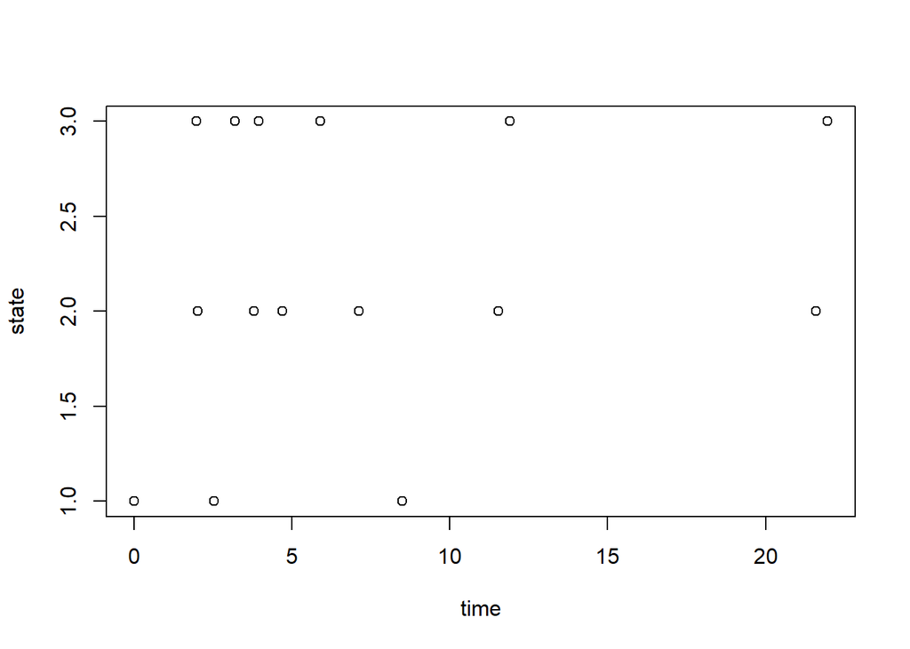

```r
plot(time, state)
```

# Q matrices

Here, we give an equivalent characterization of continuous Markov-chains taking values on a state space $S=\{1,2,3, \ldots, n\}$. Given that we are in a state $i$, it suffices to specify the mechanism for which we jump to state $j$. Let $Q$ be a $n \times n$ matrix such that $q_{ij} \geq 0$ for all $i \not =j$, and for convenience set
$$q_{ii} :=
-\sum_{j} q_{ij},$$
so that each row sums to *zero*. Sometimes $Q$ is called a **transition rate matrix** or simply the $Q$ matrix. If we are at state $i$, then we generate independent exponential random variables $(E_{ij})_{j=1} ^n$ with *rate* $q_{ij}$; the one that happens first, the minimum is the state we go to; that is, if $E_{ij}= E_i:= \min\{ E_{i1}, \ldots, E_{in}\}$ then, we jump to state $j$ after time $E_{ij}$; we take the convention that $E_{ii} =\infty$, an exponential of rate $0$. Recall that the minimum of exponentials is again and exponential, $E_i$ has rate $-q_{ii}$. Notice that the probability of going from state $i$ to $j$ is precisely,
$$m_{ij} = \mathbb{P}(E_{ij} = E_i),$$

where $m_{ii} =0$. You might recall an exercise that you did in a previous module. If $W$ and $Z$ are independent exponential random variables with rates $\lambda$ and $\mu$ then
$$\begin{eqnarray*}
\mathbb{P}(W <Z )
&=& \int_0 ^{\infty } \mu e^{-\mu y} \Bigg( \int_0
^y \lambda e^{-\lambda x} dx \Bigg) dy \\
&=& \int_0 ^{\infty } \mu e^{-\mu y} [1- e^{-\lambda
y} ] dy \\
&=& 1- \frac{\mu}{\mu+ \lambda} \\
&=& \frac{\lambda}{\mu + \lambda}.
\end{eqnarray*}$$

Hence it is not hard to believe that for $i\not = j$ we have,
$$m_{ij} = \frac{q_{ij}}{-q_{ii}}.$$
Thus we see that the $Q$ matrix description is equivalent to the mean holding time description, where we have the relation $-q_{ii} = 1/h_i$.

# Transition semigroups

Let $X$ be a continuous-time Markov chain. The **transition matrix semigroup** is given by
$$P_{ij}(t) = \mathbb{P}(X(t)=j| X(0) =
i).$$
The maths is a bit more technical than the case of discrete time Markov chains. The key observation is that the following **forward equation** is satisfied
$$P'(t) = P(t)Q.$$

To see why, observe that when $h$ is small, we assume there is at most one jump, and
$$p_{kj}(h) \approx \mathbb{P}(E_{kj} \leq h)
= 1-e^{-q_{kj}h} \approx q_{kj}h$$
for $k \not = j$. And for $k = j$, we assume that there are no jumps, so that

$$p_{jj}(h) \approx \mathbb{P}(E_j >h)
= e^{q_{jj}h} \approx 1 + q_{jj}h.$$

Thus
$$\begin{eqnarray*}
\frac{p_{ij}(t+h) - p_{ij}(t)}{h} &=& \frac{1}{h} \big( \sum_{k}
p_{ik}(t)p_{kj}(h) -p_{ij}(t)\big) \\
&=& \frac{1}{h} \big(\sum_{k \not = j} p_{ik}(t)p_{kj}(h) +
p_{ij}(t)p_{jj}(h) - p_{ij}(t) \big) \\
&\approx& \sum_{k\not =j} p_{ik}(t)q_{kj} + p_{ij}(t)q_{jj} \\
&=& [P(t)Q]_{ij}
\end{eqnarray*}$$

The first order theory of differential equations tells us that
$$P(t) = e^{tQ} := \sum_{k=0} ^{\infty} \frac{t^k
Q^k}{k!}.$$

Note that the Markov property

$$P(t+s) = P(t) P(s)$$

is the semigroup property of solutions to differential equations. Sometimes the $Q$ matrix is called the **generator** of the semigroup.

# Stationarity

Let $P$ be a transition matrix semigroup for a continuous-time Markov chain on a finite number of states $A$ with generator $Q$. We say that a probability measure $\pi$ on $A$ is a **stationary** distribution for $P$ if for all $t \geq 0$ we have

$$\pi P(t) = \pi;$$

It turns out that this condition equivalent to requiring that

$$\pi Q = \mathbf{0},$$
where $\mathbf{0}$ is the vector of all zeroes with $|A|$ components. It is easy to see that the condition on $Q$ implies the condition on $P$, but other direction is harder.

We say that $P$ is **irreducible** if for all $i, j \in A$ there exists $t >0$ such that $P_{ij}(t) >0$; note that this condition is equivalent to the corresponding jump chain having an irreducible transition matrix. Notice that the notion of periodicity does not really exist for continuous-time Markov chains, since the chain can jump at any time with nonzero probability. In particular, even if the corresponding transition matrix of the jump chain is periodic this does not transfer over to its continuous counterpart.

**Theorem:** Let $P$ be a transition matrix semigroup for an irreducible continuous-time Markov chain on a finite number of states $A$, then it has a unique stationary distribution $\pi$ and $P_{ij}(t) \to \pi(j)$ as $t \to \infty$ for all $i,j \in A$.

To identify the stationary distribution, we follow a corresponding discrete time Markov chain at times $(nr)_{n \in \mathbb{Z}^{+}}$ for some positive rational $r>0$, which has transition matrix given by $B= P(r)$. Notice that $B$ is irreducible and also aperiodic. Thus our convergence theory for discrete-time Markov chains tells us that it has the stationary distribution $\pi^r$ and
$$b_{ij}(n) = P_{ij}(rn) \to \pi^r_j.$$
Now, if we considered a different rational number $s >0$, we obtain that

$$P_{ij}(sn) \to \pi^s$$

for a possibly different measure $\pi^s$. However, since $s$ and $r$ are rational, $rn = sm$ for infinitely many positive integers $n,m$, thus we $\pi^r = \pi$ is the same measure for all positive rationals $r$. A standard *uniform* continuity argument gives that the desired limit holds.

**Exercise** Argue the uniqueness part of the convergence theorem.

**Theorem:** Let $P$ be a transition matrix semigroup for an irreducible continuous-time Markov chain on a finite number of states $A$ with the stationary measure $\pi$. Let $Q$ be the generator. Let $M$ be transition matrix for the corresponding jump chain with the corresponding stationary measure $\hat{\pi}$, then

$$\pi_i = \frac{ \hat{\pi_i} q_{ii}^{-1}
} {\sum_{j} \hat{\pi}_j (q_{jj})^{-1}}$$

and

$$\hat{\pi}_i = \frac{q_{ii} \pi_i}{\sum_j
q_{jj} \pi_j }.$$

*Proof:* These relations are readily verified using the facts that $\pi Q = \mathbf{0}$ and $m_{ij} = -\frac{q_{ij}}{q_{ii}}$ for $i \not = j$ and $m_{ii} = 0$

# Summary

- We defined continuous-time Markov chains on a finite number of states using two approaches: from the jump chain and from the $Q$ matrix.
- We introduced some code that let us visualize this processes.
- We briefly discussed the $Q$ matrix as a generator for the transition matrix semigroup $P$
- We discussed convergence theorems for $P$, by using convergence theroems for discrete-time Markov chains.

## Endnotes

- Standard references include:
  - Grimmett and Stirzker [(2001)](https://zbmath.org/1015.60002)
  - Norris [(1997)](https://zbmath.org/0873.60043)
- Version: 20 April 2024
- [Rmd Source](https://tsoo-math.github.io/ucl/continuous-timeMC.Rmd)